# Figure 2

severhart2

Tue Apr 3 01:25:20 2018

## Reading in Data and Example Analysis

In this exercise, we will learn how to read in data as an object in R, find and load packages into our library, and then re-create Figure 2 from the 2017 paper by Morini et al. paper “Control of white mold of dry bean and residual activity of fungicides applied by chemigation.”

We can use the `read.table()` function to read these data in to R. It’s important to remember that while in R, these data are simply a copy kept *in memory*, not on the disk, so we don’t have to worry too much about accidentally deleting the data :).

So, how do we actually USE the `read.table()` function? A good first step to figuring out how you can use a function is to look at it’s help page. The way you can do that is by typing either help(“function_name”) or ?function_name.

```r
     # Type ?read.table and answer these three questions:
     #
     # 1. What does it do? (Description)
     # 2. What are the first three arguments and their defaults? (Usage/Arguments)
     # 3. What does it return? (Value)
```

In order to read our data into R, we will need to provide three things:

1. The path to the data set : Results2017_combined-class.csv
2. If the first row are column names : yes
3. The separator for each cell in the data : comma

Now that we have these elements, we can read our data into a variable, which we can call “res” because it is short for “results”. Once we do this, we should check the dimensions to make sure that we have all of the data.

Now we can read in the data and inspect to make sure it is what we expect.

```r
res <- read.csv("Results2017_combined-class.csv", head = TRUE, stringsAsFactors = FALSE)
head(res)
```

```
##   DAI Number Your.name   Area      Treatment Block
## 1   1      1      Noel 19.808        control     1
## 2   1      2      Noel  9.371  2.53 mm water     1
## 3   1      3      Noel  0.000  5.07 mm water     1
## 4   1      4      Noel  0.531 10.13 mm water     1
## 5   1      5       Lee  0.000 10.13 mm water     2
## 6   1      6       Lee 20.914        control     2
```

```r
dim(res)
```

```
## [1] 288   6
```

```r
# Thinking before doing: Your data and the analysis
```

```r
#
# The example data presented here were collected by students in the 2017
# PLPT802 class and should represent the same data that this year's class collected.
# This data consists of six columns of data: DAI, Number, Your.name, Area, Treatment, and Block.
# With these data, we want to answer the following questions:
#
#  1. Can we convert lesion areas to a measurement that is relative to the control?
#  2. What do we want to plot in order to demonstrate the residual disease control over
#     time by treatment?
#
# To answer these questions, we will need to manipulate the layout of the data and will also
# need to write a function to perform a calculation and then plot the results of the
# calculations over time.  Not all data manipulations will be described in detail here and
# are shown so that you can re-run this analysis using data collected in class.  We will
# do this using the following four steps:
#
#    1. Create a function
#    2. Spread the data in different columns by treatment
#    3. Calculate percent disease control
#    4. Summarize the average lesion area in a plot
#
#
```

# Preparing Data and Packages

We will re-create the figure using three packages dplyr, tidyr, and ggplot2. These packages add flexibility to data and figure manipulations. We will not go into these in detail. Refer to the tab in this website called “Other Exercises” to get started learning more.

```r
library("dplyr")
library("tidyr")
library("ggplot2")
```

## Reordering factors

The factors in the treatments will be out of order when plotting because it’s always alphabetical by default (and 1 comes before 2). Here we are reordering the factors:

```r
unique(res$Treatment) # The correct order
```

```
## [1] "control"        "2.53 mm water"  "5.07 mm water"  "10.13 mm water"
```

```r
res <- mutate(res, Treatment = factor(Treatment, levels = unique(Treatment)))
levels(res$Treatment)
```

```
## [1] "control"        "2.53 mm water"  "5.07 mm water"  "10.13 mm water"
```

# Calculating Percent Disease Control

Percent disease control is “estimated as the difference in lesion area of the control and treatment, divided by lesion area of the control and expressed as percent.” Because we will have to make this calculation many times, it’s best to write a function for it.

## Step 1: Create a function

Our function will take in two numbers, the lesion area of the control and the lesion area of the treatment.

```r
percent_control <- function(control, treatment){
  res <- (control - treatment)/control # estimate the disease control
  return(res*100)                      # express as percent
}
```

We can show that this works:

```r
percent_control(control = 10, treatment = 5)
```

```
## [1] 50
```

## Step 2: Spread the data in different columns by treatment

Our data were recorded in a “tidy” fashion in which we had one observation per row. In order to calculate the percent control, we’ll need to rehshape our data so that we have one column per treatment such that each row will represent a single block per day after application. We’ll use the *tidyr* function `spread()` to do this.

```r
blocks <- res %>%
  select(DAI, Block, Treatment, Area) %>% # We don't need name or number here
  spread(Treatment, Area) # make new columns from treatment, and fill with Area
blocks
```

```
##    DAI Block control 2.53 mm water 5.07 mm water 10.13 mm water
## 1    1     1  19.808         9.371         0.000          0.531
## 2    1     2  20.914         0.000         0.173          0.000
## 3    1     3  15.206        21.173         0.000         18.270
## 4    1     4  11.598         0.000         5.736          9.524
## 5    1     5   3.034         0.000         0.458          1.943
## 6    1     6   8.770        12.053        13.148          0.000
## 7    1     7  12.951         0.000        15.283         14.839
## 8    1     8  20.537         0.000        12.080          1.737
## 9    1     9  25.941         0.000         7.428          1.592
## 10   1    10  22.998         3.106         0.000          7.679
## 11   1    11  15.302         0.000        20.567          0.000
## 12   1    12  23.496         0.000        14.778          0.000
## 13   3     1   4.853        18.860         1.632         10.572
## 14   3     2  20.540         0.000         5.032          0.000
```

[output cut: 58 more lines]

## Step 3: Calculate percent disease control

Now that we have reshaped our data, we can manipulate each treatment column to give us the percent control.

```r
# Note: the backtics "`" allow R to recognize a variable with spaces.
percents <- blocks %>%
  mutate(`2.53 mm water`  = percent_control(control, `2.53 mm water`)) %>%
  mutate(`5.07 mm water`  = percent_control(control, `5.07 mm water`)) %>%
  mutate(`10.13 mm water` = percent_control(control, `10.13 mm water`)) %>%
  mutate(control          = percent_control(control, 0))
percents
```

```
##    DAI Block control 2.53 mm water 5.07 mm water 10.13 mm water
## 1    1     1     100     52.690832   100.0000000      97.319265
## 2    1     2     100    100.000000    99.1728029     100.000000
## 3    1     3     100    -39.241089   100.0000000     -20.149941
## 4    1     4     100    100.000000    50.5431971      17.882394
## 5    1     5     100    100.000000    84.9044166      35.959130
## 6    1     6     100    -37.434436   -49.9201824     100.000000
## 7    1     7     100    100.000000   -18.0063316     -14.578025
## 8    1     8     100    100.000000    41.1793349      91.542095
## 9    1     9     100    100.000000    71.3657916      93.862997
## 10   1    10     100     86.494478   100.0000000      66.610140
## 11   1    11     100    100.000000   -34.4072670     100.000000
## 12   1    12     100    100.000000    37.1041879     100.000000
## 13   3     1     100   -288.625592    66.3713167    -117.844632
## 14   3     2     100    100.000000    75.5014606     100.000000
```

[output cut: 58 more lines]

Because figure 2 plotted the average value, we want to summarize our data in averages. To do this, we need to convert our data back to tidy format by using the *tidyr* function `gather()`:

```r
percents <- percents %>%
  gather(key = Treatment, value = Area, -DAI, -Block) %>%
  mutate(Treatment = factor(Treatment, levels = unique(Treatment))) # reset factor
percents
```

```
##     DAI Block      Treatment          Area
## 1     1     1        control   100.0000000
## 2     1     2        control   100.0000000
## 3     1     3        control   100.0000000
## 4     1     4        control   100.0000000
## 5     1     5        control   100.0000000
## 6     1     6        control   100.0000000
## 7     1     7        control   100.0000000
## 8     1     8        control   100.0000000
## 9     1     9        control   100.0000000
## 10    1    10        control   100.0000000
## 11    1    11        control   100.0000000
## 12    1    12        control   100.0000000
## 13    3     1        control   100.0000000
## 14    3     2        control   100.0000000
```

[output cut: 274 more lines]

## Step 4: Summarize the average lesion area

We can summarize the average area per DAI and Treatment, which will allow us to plot the data in the manner of Morini *et al.* 2017.

```r
avgs <- percents %>%
  group_by(DAI, Treatment) %>%
  summarize(meanArea = mean(Area)) %>%
  ungroup()
avgs
```

```
## # A tibble: 24 x 3
##      DAI Treatment      meanArea
##    <int> <fct>             <dbl>
##  1     1 control          100
##  2     1 2.53 mm water     71.9
##  3     1 5.07 mm water     48.5
##  4     1 10.13 mm water    64.0
##  5     3 control          NaN
##  6     3 2.53 mm water   -Inf
##  7     3 5.07 mm water    NaN
##  8     3 10.13 mm water   NaN
##  9     5 control          100
## 10     5 2.53 mm water      7.55
## # ... with 14 more rows
```

Now that we have our averages, we can plot it using *ggplot2*

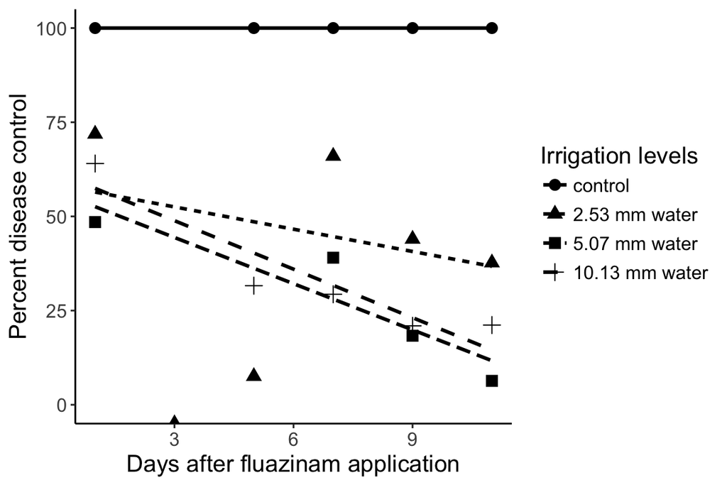

```r
ggplot(avgs, aes(x = DAI, y = meanArea, group = Treatment)) +
  geom_point(aes(pch = Treatment), size = 3) + # plot the points
  stat_smooth(aes(lty = Treatment), method = "lm", se = FALSE, color = "black") + # plot the regression
  theme_classic() + # change the appearance
  ylim(0, 100) + # set the limits on the y axis
  theme(text = element_text(size = 14)) + # increase the text size
  labs(list( # Set the labels
    x = "Days after fluazinam application",
    y = "Percent disease control",
    pch = "Irrigation levels",
    lty = "Irrigation levels"))
```

# Additional visualizations

When we plot the averages, we inadvertently hide the data. Of course, if we tried to plot all the data in one graph, it would look a bit messy:

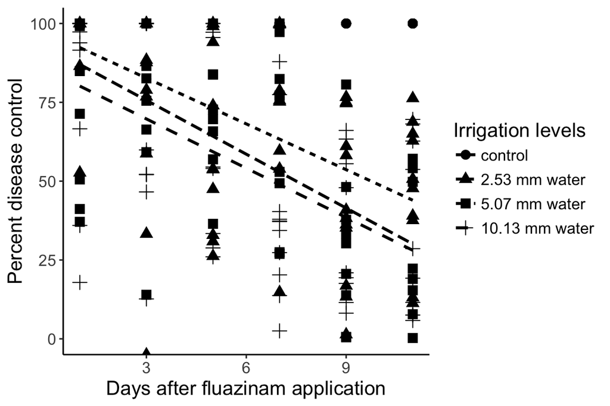

```r
ggplot(percents, aes(x = DAI, y = Area, group = Treatment)) +
  geom_point(aes(pch = Treatment), size = 3) + # plot the points
  stat_smooth(aes(lty = Treatment), method = "lm", se = FALSE, color = "black") + # plot the regression
  theme_classic() + # change the appearance
  ylim(0, 100) + # set the limits on the y axis
  theme(text = element_text(size = 14)) + # increase the text size
  labs(list( # Set the labels
    x = "Days after fluazinam application",
    y = "Percent disease control",
    pch = "Irrigation levels",
    lty = "Irrigation levels"))
```

With ggplot2, we can spread the data out into “facets”:

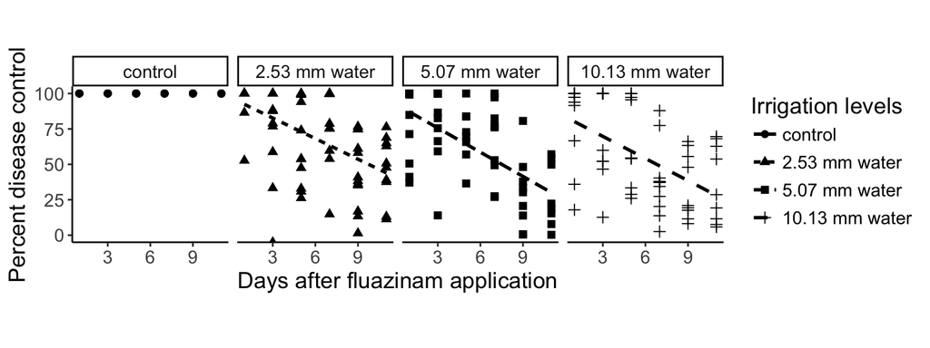

```r
ggplot(percents, aes(x = DAI, y = Area, group = Treatment)) +
  geom_point(aes(pch = Treatment), size = 2) + # plot the points
  stat_smooth(aes(lty = Treatment), method = "lm", se = FALSE, color = "black") + # plot the regression
  theme_classic() + # change the appearance
  ylim(0, 100) + # set the limits on the y axis
  theme(text = element_text(size = 14)) + # increase the text size
  facet_wrap(~Treatment, nrow = 1) +
  theme(aspect.ratio = 1) +
  labs(list( # Set the labels
    x = "Days after fluazinam application",
    y = "Percent disease control",
    pch = "Irrigation levels",
    lty = "Irrigation levels"))
```